# Sentiment Analysis

The purpose of the project is to classify the text to the associated emotions. Here we use different Machine learning algorithm such as multinomial Naive Bayes, Logistic regression, Decision tree, Random forest, SVM and KNN Classifier to classify the text into 6 emotions classes.

The Data sets content 20,000 text along with the associated emotions. We have three text files train, test and validation with 16000, 2000, and 2000 instance respectively. Here in this project we combine all the instance in one and split the dataset into training and testing based on 80 /20 % spliting rule.

We Preprocess the text before fitting into the ML models. First we perform text preprocessing where we implement basic techniques used for NLP Text preprocessing. Later the preprocessed text is vectorized and use IFIDF technique to turn the preprocessed text into features which is later fited into the machine learning models. We fit the data in the training set and perform the testing in the 20 % testing dataset. Finally we check the predictions for the new instance with the previously fitted models.

```python
import warnings
warnings.filterwarnings('ignore')
import pandas as pd
```

```python
# Read datasets
df_train = pd.read_csv('/content/train.txt', names=['Text', 'Emotion'], sep=';')
df_val = pd.read_csv('/content/val.txt', names=['Text', 'Emotion'], sep=';')
df_test = pd.read_csv('/content/test.txt', names=['Text', 'Emotion'], sep=';')
```

```python
# Display the shapes of the dataframes
print("Shape of df_train:", df_train.shape)
print("Shape of df_val:", df_val.shape)
print("Shape of df_test:", df_test.shape)
```

```
Shape of df_train: (16000, 2)
Shape of df_val: (2000, 2)
Shape of df_test: (2000, 2)
```

```python
# Concatenate dataframes
df = pd.concat([df_train, df_val, df_test])
df.shape
```

```
(20000, 2)
```

```python
df.head()
```

|  | Text | Emotion |
| --- | --- | --- |
| 0 | i didnt feel humiliated | sadness |
| 1 | i can go from feeling so hopeless to so damned... | sadness |
| 2 | im grabbing a minute to post i feel greedy wrong | anger |
| 3 | i am ever feeling nostalgic about the fireplac... | love |
| 4 | i am feeling grouchy | anger |

```python
df.isnull().sum()
```

```
Text       0
Emotion    0
dtype: int64
```

```python
# Find duplicate rows based on text columns
duplicate_rows = df[df.duplicated(subset='Text', keep = False)]
# Print duplicate rows
print(duplicate_rows)
```

```
                                                   Text   Emotion
112   i feel like some of you have pains and you can...      love
364   i tend to stop breathing when i m feeling stre...   sadness
556   i feel completely blessed to be a part of this...      love
1372  i loved the feeling i got during an amazing sl...  surprise
1501  i feel on the verge of tears from weariness i ...      love
...                                                 ...       ...
959                       i feel cared for and accepted      love
1026  i have not conducted a survey but it is quite ...   sadness
1275  i feel so weird and scattered with all wonders...  surprise
1826  i don t always feel like i have amazing style ...       joy
1887  i feel like some of you have pains and you can...       joy

[104 rows x 2 columns]
```

```python
# Initialize a counter
counter = 0

# Iterate over each duplicate row
for index, row in duplicate_rows.iterrows():
    # Check if counter reaches 5
    if counter >= 2:
        break

    # Find rows that are duplicates of the current row
    matching_rows = df[df['Text'] == row['Text']]

    # Print information about the duplicate rows
    print(f"Duplicate row at index {index}:")
    print(row)
    print("Duplicates with:")
    print(matching_rows)
    print()

    # Increment the counter
    counter += 1
```

```
Duplicate row at index 112:
Text       i feel like some of you have pains and you can...
Emotion                                                 love
Name: 112, dtype: object
Duplicates with:
                                                   Text Emotion
112   i feel like some of you have pains and you can...    love
1887  i feel like some of you have pains and you can...     joy

Duplicate row at index 364:
Text       i tend to stop breathing when i m feeling stre...
Emotion                                              sadness
Name: 364, dtype: object
Duplicates with:
                                                   Text  Emotion
364   i tend to stop breathing when i m feeling stre...  sadness
6563  i tend to stop breathing when i m feeling stre...    anger
```

```python
# Find duplicate rows based on text columns and keep the first duplicates
duplicate_rows = df[df.duplicated(subset='Text', keep = 'first')]

# Print the count of duplicate rows
print(duplicate_rows.shape[0])
```

```
52
```

```python
df = df.drop_duplicates(subset='Text', keep='first')
df.shape
```

```
(19948, 2)
```

```python
# Count the values of emotions
emotion_counts = df['Emotion'].value_counts()
emotion_counts
```

```
joy         6739
sadness     5793
anger       2703
fear        2369
love        1630
surprise     714
Name: Emotion, dtype: int64
```

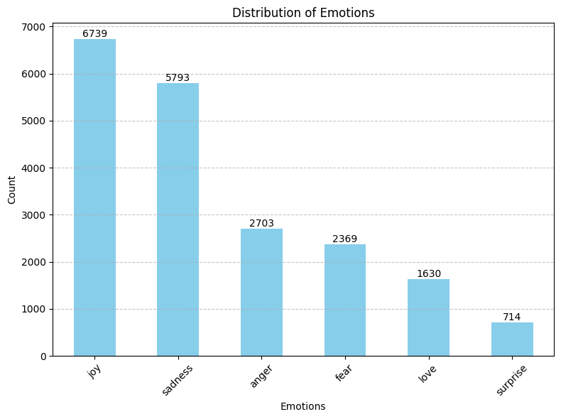

```python
import matplotlib.pyplot as plt

# Plot bar graph
plt.figure(figsize=(8, 6))
emotion_counts.plot(kind='bar', color='skyblue')
plt.title('Distribution of Emotions')
plt.xlabel('Emotions')
plt.ylabel('Count')
plt.xticks(rotation=45)
plt.grid(axis='y', linestyle='--', alpha=0.7)

# Add counts at the top of each bar
for index, value in enumerate(emotion_counts):
    plt.text(index, value + 0.1, str(value), ha='center', va='bottom')

plt.tight_layout()
plt.show()
```

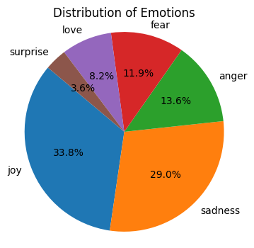

```python
# Plot pie chart
plt.figure(figsize=(4, 4))
plt.pie(emotion_counts, labels=emotion_counts.index, autopct='%1.1f%%', startangle=140)
plt.title('Distribution of Emotions')
plt.axis('equal')  # Equal aspect ratio ensures that pie is drawn as a circle.
plt.show()
```

# Text Preprocessing

```python
import nltk
nltk.download('punkt')
```

```
True
```

```python
nltk.download('stopwords')
```

```
True
```

```python
nltk.download('wordnet')
```

```
True
```

```python
from nltk.corpus import stopwords
from nltk.tokenize import word_tokenize
from nltk.stem import WordNetLemmatizer
import string
```

```python
# Function to preprocess text
def preprocess_text(text):
    # Tokenization
    tokens = word_tokenize(text.lower())

    # Remove punctuation
    tokens = [token for token in tokens if token not in string.punctuation]

    # Remove stopwords
    stop_words = set(stopwords.words('english'))
    tokens = [token for token in tokens if token not in stop_words]

    # Lemmatization
    lemmatizer = WordNetLemmatizer()
    tokens = [lemmatizer.lemmatize(token) for token in tokens]

    # Join tokens back into a string
    preprocessed_text = ' '.join(tokens)

    return preprocessed_text
```

```python
# Apply preprocessing function element-wise to the "Text" column
df['Preprocessed_text'] = df['Text'].apply(preprocess_text)
df.head()
```

|  | Text | Emotion | Preprocessed_text |
| --- | --- | --- | --- |
| 0 | i didnt feel humiliated | sadness | didnt feel humiliated |
| 1 | i can go from feeling so hopeless to so damned... | sadness | go feeling hopeless damned hopeful around some... |
| 2 | im grabbing a minute to post i feel greedy wrong | anger | im grabbing minute post feel greedy wrong |
| 3 | i am ever feeling nostalgic about the fireplac... | love | ever feeling nostalgic fireplace know still pr... |
| 4 | i am feeling grouchy | anger | feeling grouchy |

# Visualizations and getting insights from the data

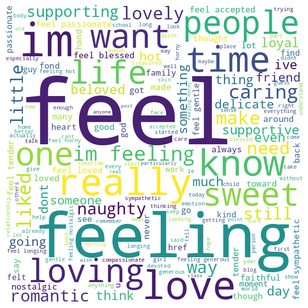

```python
from wordcloud import WordCloud

# Function to concatenate preprocessed words for a specific sentiment
def concatenate_words(df, sentiment):
    filtered_words = ' '.join(df[df['Emotion'] == sentiment]['Preprocessed_text'])
    return filtered_words

# Function to plot word cloud for a specific sentiment
def plot_wordcloud(df, sentiment):
    # Generate word cloud
    sentiment_words = concatenate_words(df, sentiment)
    wordcloud = WordCloud(width=600, height=600,
                          background_color='white',
                          stopwords=None,
                          min_font_size=8).generate(sentiment_words)

    # Plot word cloud
    plt.figure(figsize=(6, 6), facecolor=None)
    plt.imshow(wordcloud)
    plt.axis("off")
    plt.tight_layout(pad=0)
    plt.show()

# Word Cloud For love
plot_wordcloud(df, 'love')
```

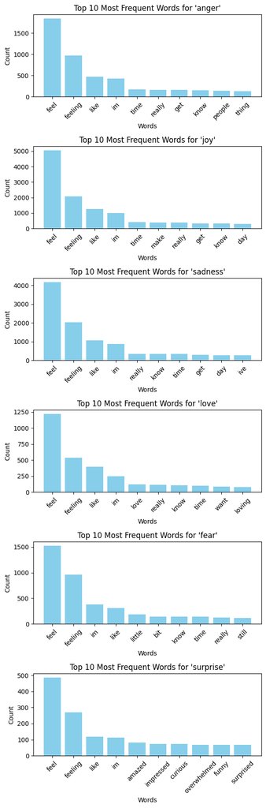

```python
from collections import Counter
import matplotlib.pyplot as plt

# Function to count the occurrences of the most frequent words for each sentiment
def plot_most_frequent_words(df, sentiments):
    # Initialize a subplot for each sentiment
    num_rows = len(sentiments)
    fig, axes = plt.subplots(num_rows, 1, figsize=(6, 3*num_rows))

    # Iterate over each sentiment
    for i, sentiment in enumerate(sentiments):
        # Filter preprocessed words based on sentiment
        sentiment_words = ' '.join(df[df['Emotion'] == sentiment]['Preprocessed_text'])

        # Tokenize the filtered words
        words_list = sentiment_words.split()

        # Count the occurrences of each word
        word_counts = Counter(words_list)

        # Get the most common words
        most_common_words = dict(word_counts.most_common(10))

        # Plot bar graph for the current sentiment
        ax = axes[i]
        ax.bar(most_common_words.keys(), most_common_words.values(), color='skyblue')
        ax.set_title(f"Top 10 Most Frequent Words for '{sentiment}'")
        ax.set_xlabel('Words')
        ax.set_ylabel('Count')
        ax.tick_params(axis='x', rotation=45)

    plt.tight_layout()
    plt.show()

# Example usage
sentiments = ['anger', 'joy', 'sadness', 'love', 'fear', 'surprise']  # Specify which sentiments to analyze
plot_most_frequent_words(df, sentiments)
```

```python
# df['Emotion_label'] = df['Emotion'].map({
#     'joy' : 0,
#     'sadness': 1,
#     'anger': 2,
#     'fear': 3,
#     'love': 4,
#     'surprise':5
# })

# df.head(5)
```

# Model Building

- Multinomial Naive Bayes
- Logistic Regression
- Decision Tree
- Random Forest
- KNN
- SVM

```python
from sklearn.pipeline import Pipeline
from sklearn.model_selection import train_test_split
from sklearn.feature_extraction.text import CountVectorizer, TfidfTransformer
from sklearn.naive_bayes import MultinomialNB
from sklearn.linear_model import LogisticRegression
from sklearn.neighbors import KNeighborsClassifier
from sklearn.tree import DecisionTreeClassifier
from sklearn.ensemble import RandomForestClassifier
from sklearn.svm import SVC
from sklearn.metrics import classification_report, accuracy_score, confusion_matrix
```

```python
X = df['Preprocessed_text']
#y = df['Emotion_label']
y = df['Emotion']

# Split the data into training and testing sets
X_train, X_test, y_train, y_test = train_test_split(X, y, stratify = y, test_size=0.2, random_state=42)
```

```python
print(X_train.shape, y_test.shape)
```

```
(15958,) (3990,)
```

```python
# Define classifiers
classifiers = {
    'Multinomial Naive Bayes': MultinomialNB(),
    'Logistic Regression': LogisticRegression(max_iter=1000),
    'K-Nearest Neighbors': KNeighborsClassifier(),
    'Decision Tree': DecisionTreeClassifier(random_state=42),
    'Random Forest': RandomForestClassifier(random_state=42),
    'Support Vector Machine': SVC()
}

# Evaluate each classifier
for classifier_name, classifier in classifiers.items():
    print("#" * 50)
    print(f"Evaluating {classifier_name}...")
    print("#" * 50)
    # Define the text processing and classification pipeline with the current classifier
    text_classification_pipeline = Pipeline([
        ('vect', CountVectorizer()),
        ('tfidf', TfidfTransformer()),
        ('clf', classifier),
    ])

    # Fit the pipeline to the training data
    text_classification_pipeline.fit(X_train, y_train)

    # Predict on the testing data
    y_pred = text_classification_pipeline.predict(X_test)

    # Calculate accuracy
    accuracy = accuracy_score(y_test, y_pred)

    # Print classification report and accuracy
    print(classification_report(y_test, y_pred))
    print(f"Accuracy of {classifier_name} : {accuracy:.2f}")

    # Print confusion matrix
    print(f"Confusion Matrix of {classifier_name}:")
    print(confusion_matrix(y_test, y_pred))
    print('\n')
```

```
##################################################
Evaluating Multinomial Naive Bayes...
##################################################
              precision    recall  f1-score   support

       anger       0.96      0.33      0.49       540
        fear       0.94      0.25      0.39       474
         joy       0.64      0.98      0.77      1348
        love       0.95      0.06      0.12       326
     sadness       0.67      0.93      0.78      1159
    surprise       1.00      0.01      0.01       143

    accuracy                           0.68      3990
   macro avg       0.86      0.42      0.43      3990
weighted avg       0.77      0.68      0.61      3990

Accuracy of Multinomial Naive Bayes : 0.68
Confusion Matrix of Multinomial Naive Bayes:
[[ 176    1  178    0  185    0]
 [   7  117  149    0  201    0]
 [   0    0 1317    1   30    0]
 [   1    0  242   20   63    0]
 [   0    0   83    0 1076    0]
 [   0    6   87    0   49    1]]


##################################################
Evaluating Logistic Regression...
##################################################
              precision    recall  f1-score   support

       anger       0.90      0.81      0.85       540
        fear       0.88      0.77      0.82       474
         joy       0.85      0.95      0.90      1348
        love       0.85      0.64      0.73       326
     sadness       0.89      0.95      0.92      1159
    surprise       0.92      0.55      0.69       143

    accuracy                           0.87      3990
   macro avg       0.88      0.78      0.82      3990
```

[output cut: 78 more lines]

[output not shown]

```python
# New instance text
new_instance_text = "I feel happy and excited about the upcoming event"

# Preprocess the new instance
preprocessed_new_instance = preprocess_text(new_instance_text)

# Define CountVectorizer and TfidfTransformer
vectorizer = CountVectorizer()
tfidf_transformer = TfidfTransformer()

# Vectorize the text data
X_train_counts = vectorizer.fit_transform(X_train)
X_train_tfidf = tfidf_transformer.fit_transform(X_train_counts)

# Vectorize the new instance text
new_instance_counts = vectorizer.transform([new_instance_text])
new_instance_tfidf = tfidf_transformer.transform(new_instance_counts)

# Make predictions using each classifier
for classifier_name, classifier in classifiers.items():
    print(f"Predictions using {classifier_name}:")

    # Predict on the vectorized new instance
    prediction = classifier.predict(new_instance_tfidf)
    print(f"Prediction: {prediction[0]}")
    print("-" * 50)
```

[output not shown]

```python
# Example of a new instance
new_instance = "I FEEL LOVED BUT SOMETIME angry and furious about this product"

# Preprocess the new instance
preprocessed_new_instance = preprocess_text(new_instance)

# Use the trained classifier to predict the label for the preprocessed new instance
predicted_label = text_classification_pipeline.predict([preprocessed_new_instance])

print("Predicted Label:", predicted_label[0])
```

[output not shown]